# Chatham Strait Sablefish Stock Assessment

Jane Sullivan

Tue May 01 07:49:02 2018

Co-author(s): Ben Williams and Andrew Olson

To: Andrew Olson, Karla Bush Cc: Chris Siddon, Ben Williams, Sara Miller, Katie Palof

DATES  
Presentation to industry: Wednesday, March 7; Initial Draft: Tuesday, May 1; Internal ADF&G review: Thursday, May 10;  
Final version approved by reviewers & managers: Friday, May 13;  
Public announcement of formal quota: **TBD**

# Summary

# Changes to the NSEI sablefish assessment for 2018 relative to 2017

1. The NSEI Chatham Strait sablefish assessment was developed into a reproducible research product (de Leeuw 2001). It is publically hosted on the web-based version control service GitHub at https://github.com/commfish/seak_sablefish. This effort included a thorough review of all data sources available for the NSEI. It involved detailed conversation with ADF&G programming staff, Scott Johnson and Paul Caldwell, as well as Region I Groundfish Project biologists, Andrew Olsen, Aaron Baldwin, and Mike Vaughn.The outcomes of these discussions are documented in software code, README file, and Issues tab of the `seak_sablefish` repository. This product is considered *conditionally reproducible*, indicating that potential users must formally request any confidental data sourced in the code in order to produce the full assessment (Schwab et al. 2000). However, survey and other non-confidential data are made available, and all queries and subsequent transformations to the data are included in the analysis.
2. The mark-recapture models used in this analysis are based on analyses by Dr. Franz Mueter (Mueter 2010). We compare population estimates from a simple Chapman estimator with estimates from several extensions of a stratified Peterson estimator that account for changes in capture probability through time, natural and fishing mortality, migration, and seasonal trends in catch rates. These alternative model structures are implemented in the Bayesian open source software JAGS 4.3.0 (Depaoli 2016). Previous methods used arbitrary break points (e.g. 5 or 10 days) to define temporal strata throughout the fishing season (Mueter 2010, van Kirk et al. 2016). Here we use cumulative catch over time to define temporal strata. We use a combination of convergence criteria, deviance information criterion (DIC; Spiegelhalter et al. 2002), and a visual examination of how well the model tracked seasonal trends in abundance to aid in model selection.

# Section I: 2017 Acceptable Biological Catch (ABC)

# Section II: Mark-recapture methods

The mark-recapture project forms the foundation for current sablefish management in Chatham Strait and will scale absolute abundance in a future age-structured assessment model. The most commonly used method used for abundance estimation and the model that was used for many years by ADF&G is the Chapman estimator:

1. $$N = \frac{(K+1)(n+1)}{k+1}-1,$$

where $N$ is the estimated population abundance, $K$ is the total number of individuals marked in the population, $n$ is the number of individuals checked for marks at the time of recapture, and $k$ is the number of marked individuals out of $n$.

```r
read_csv("output/tag_summary_report.csv") -> tag_sum
tag_sum[c(2,4)] <- lapply(tag_sum[,c(2,4)], prettyNum, trim=TRUE, big.mark=",")
```

This Chapman estimator serves as our null model (Model 0) and the basis of comparison to other models (Table 1). A description of all model variables is found in Table 2, and a coarse summary of the tag data since 2005 is found in Table 3. Note that ADF&G did not conduct a mark survey in 2011, 2014, or 2016 due to budget restrictions. We developed Models 1-4 in a Bayesian framework using JAGS 4.3.0 (Depaoli 2016). Breakpoints for temporal strata were defined by dividing cumulative catch evenly over time.

## Model 1: Time-stratified Petersen estimator

We assumed the abundance of sablefish in Chatham Straight in a given time period $N_i$ followed a normal distribution with an uninformative prior centered on past assessments’ forecast of abundance.

For any given time period $i$:

2. $$K_i = \left\{ \begin{array}{rl}
   (K_0-D_0)*exp(-M*t_i) &\mbox{i=1}\\
   (K_{i-1}-k_{i-1}-D_{i-1})*exp(-M*t_i) &\mbox{i>1}
   \end{array}\right.$$
3. $$N_i = \left\{ \begin{array}{rl}
   (N_i*exp(-M*t_i) &\mbox{i=1}\\
   (N_{i-1}-C_{i-1})*exp(-M*t_i) &\mbox{i>1}
   \end{array}\right.$$

The probability that a sablefish caught in a given time period is clipped $p_i$ is informed by the ratio of clips in population to the total population at that time ${k_i}/{N_i}$. We assume each $p_i$ follows a beta prior distribution

4. $$p_i = beta(\alpha,\beta),$$

where $\alpha=({k_i}/{N_i})*x$, $\beta=(1-{k_1}/{N_i})/x$, and the magnitude of $x$ indicates our relative confidence in ${k_i}/{N_i}$. Because we assigned a vague prior for $N_i$, we assumed $x$ at 10,000.

In a given time period, the likelihood of recapturing $k$ marked sablefish given $n$ sampled individuals then follows a binomial distribution, where

5. $$Pr(k|n,p)=\binom{n}{k}p^k(1-p)^{n-k}.$$

The final estimate and credibility interval reported for $N$ is the average $N$ across all time periods.

## Model 2: Accounting for movement

6. $$N_i=(N_{i-1}-C_{i-1})*exp(-M*t_i)+r*t_i.$$

## Models 3 and 4: Including fishery CPUE data

As an extension to the above models and to account for seasonal trends in abundance and fishing effort, we included fishery CPUE data in the model. An examination of fishery CPUE since 2005 (omited for brevity), shows slight increasing or decreasing linear trends in fishery CPUE. This suggests a change in fish abundance or density throughout the fishing season and that the direction of this change is variable between years. Fishery CPUE in a given time period (defined as number of sablefish per 1000 hooks) was back-calculated using mean fish weight in the fishery and weight of the landing from fish tickets.

Following Mueter (2010), we constructed versions of Model 1 and 2 that included the fishery CPUE data. We assumed that fishery CPUE was proportional to total sablefish abundance in each time period

7. $$CPUE_i = q * N_i,$$

where catchability $q$ is the constant of proportionality. The models including fishery CPUE data were fit to both the mark-recapture and fishery CPUE data by maximizing the combined likelihood (consisting of a binomial likelihood component for the mark-recapture data and a normal likelihood for the fishery CPUE data). Both likelihood components received equal weights in the combined likelihood, thus fishery CPUE and markrecapture data contribute equally to the parameter estimation.

## Results and model selection

A total of 32 models were fit for each mark survey year from 2005 to 2017 (10 distinct years). We visually examined trace plots and used the Gelman and Rubin’s convergence diagnstic (Gelman and Rubin 1992) to test the convergence of MCMC chains. All models were well mixed, except for versions of Models 3 and 4 with fewer than 4 time periods. Models 3 and 4 used fishery CPUE data to estimate $q$, so it makes sense that these models require more observations of CPUE (ie. more time periods) to converge. These models were omitted from further consideration.

The models with the most support in all years were Models 1 and 2 by DIC ($\Delta{DIC}\leq2$) (Burnham and Anderson 2003). The point estimate and credibility interval for $N$ (and $r$ and $q$ when appropriate) for the top candidate models for 2017 are found in Table 4. Models 1-4 estimate have much lower estimates of abundance than the simple Chapman estimator, likely because the Chapman estimator does not account for natural or fishing mortality or changes in abundance throughout the season. Although Model 2 had statistical support, the credibility intervals for net migration ($r$) were wide for all years, and the direction of net migration (positive or negative) was inconsistent across years (Figure 7). It provides an interesting contrast to the other models, but more research is needed before bringing this type of model forward for management. Models 3 and 4, though having a lower DIC weighting, had reasonable abundance estimates and fit the CPUE data well in most years (2017 was a notable expection; Figure 8). These models have potential for future development.

Ultimately, because it had the lowest DIC and was most similar to population models used for recent assessments, we selected Model 1 with $P=6$ to bring forward for the 2018 forecast and calculation of the 2018 ABC. A retrospective analysis shows that Model 1 abundance estimates follow a similar trend and general magnitude as past model estimates (Figure 9).

# Tables

Table 1. A description of the mark-recapture models compared in 2017.

| Model | Description | Parameters |
| --- | --- | --- |
| Model 0 | Chapman estimator | $N$ |
| Model 1 | Time-stratified Peterson estimator with natural mortality | $N$, $p$ |
| Model 2 | Model 1 with migration | $N$, $p$, $r$ |
| Model 3 | Model 1 with fishery CPUE data | $N$, $p$, $q$ |
| Model 4 | Model 1 with migration and fishery CPUE data | $N$, $p$, $r$, $q$ |

Table 2. Notation for models used in the 2017 stock assessment.

| Variable | Definition |
| --- | --- |
| $N_0$ | Number of sablefish in Chatham Strait at time of marking during the ADF&G pot survey |
| $K_0$ | Number of marks released in the ADF&G pot survey |
| $D_0$ | Number of marks that are not available to either the ADF&G longline survey or to the fishery (tags recovered in halibut fishery or outside of Chatham Strait) |
| $i$ | Subscript for each time period, which may refer to the ADF&G longline survey ($i$ = 1) or to one of the fishery time periods based on time of landing |
| $N_i$ | Number of sablefish in Chatham Strait at the beginning of time period $i$ |
| $D_i$ | Number of tags lost in time period $i$ that should be decremented from the next time period |
| $C_i$ | Total catch (number of sablefish removed) during time period $i$ |
| $K_i$ | Number of marked sablefish in Chatham Straight at the beginning of time period $i$ |
| $t_i$ | Number of days in time period $i$ |
| $n_i$ | Observed catch during period $i$ (number of marked and unmarked sablefish that were checked for clips or tags in the ADF&G longline survey) |
| $k_i$ | Number of marked fish recovered in period $i$ (tags in the ADF&G longline survey) |
| $p_i$ | Probability of recapture in time period $i$ |
| $M$ | Natural mortality decremented daily and fixed at 0.1 following Johnson and Quinn (1988) |
| $r$ | Net number of unmarked individuals entering or leaving Chatham Strait (migration parameter) |
| $q$ | Catchability coefficient for the fishery relating fishery CPUE in period $i$ to sablefish abundance $CPUE_i=q*N_i$ |
| $P$ | Total number of time periods |

Table 3. A summary of data inputs to the mark-recapture models, including marked individuals ($K_0$), recaptured individuals ($k$), sampled individuals ($n$), tags recaptured before the longline survey ($D_0$), and during the survey or the fishery ($D$) for years with a mark survey from 2005 to 2017.

| Year | $K_0$ | $k$ | $n$ | $D_0$ | $D$ |
| --- | --- | --- | --- | --- | --- |
| 2005 | 7,118 | 60 | 17,495 | 9 | 44 |
| 2006 | 5,325 | 26 | 14,481 | 3 | 20 |
| 2007 | 6,157 | 33 | 15,253 | 2 | 10 |
| 2008 | 5,450 | 42 | 15,483 | 4 | 12 |
| 2009 | 7,071 | 42 | 14,946 | 7 | 9 |
| 2010 | 7,443 | 54 | 14,764 | 4 | 6 |
| 2012 | 7,582 | 66 | 18,047 | 23 | 4 |
| 2013 | 7,961 | 86 | 13,570 | 24 | 3 |
| 2015 | 6,862 | 63 | 12,274 | 1 | 10 |
| 2017 | 7,096 | 39 | 14,200 | 3 | 3 |

Table 4. Results from candidate models in 2017, including abundance estimate (median) and 95% credibility intervals, deviance, parameter penalty, and delta DIC (DIC = 0 is the model with the most support).

| Model | Estimate | Upper CI | Lower CI | Deviance | Parameter penalty | delta DIC |
| --- | --- | --- | --- | --- | --- | --- |
| Model0 | 2,517,481 | NA | NA | NA | NA | NA |
| Model1 | 2,122,673 | 2,585,530 | 1,778,852 | 38.11 | 3.66 | 0.00 |
| Model2 | 2,145,708 | 2,665,681 | 1,774,421 | 38.54 | 4.05 | 0.82 |
| Model3 | 2,107,460 | 2,566,178 | 1,755,491 | 87.01 | 7.49 | 52.73 |
| Model4 | 2,202,930 | 2,765,639 | 1,806,800 | 86.23 | 9.32 | 53.78 |

# Figures

Figure 10. Proportions-at-age for males and females in the ADF&G longline survey, 1997 - 2017.

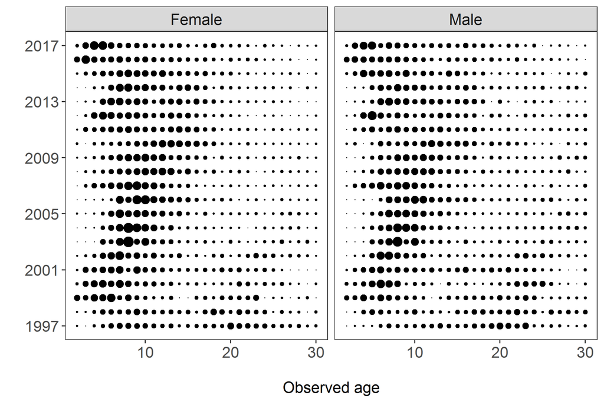

Figure 11. Proportions-at-age for males and females in the longline fishery, 2002 - 2017.

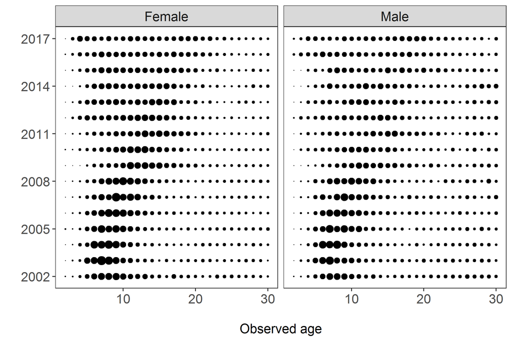

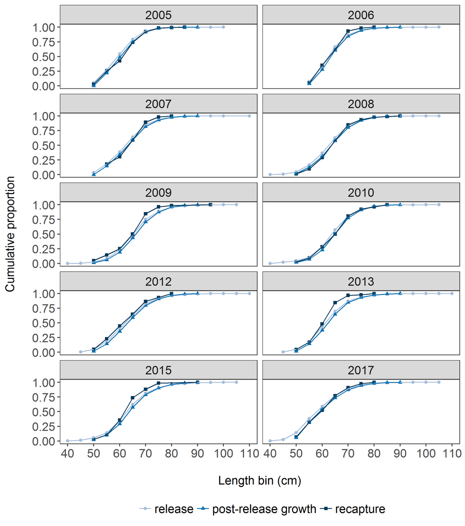

Figure 5. The probability of being recaptured in a statistical area given release area, 2005 - 2017. Statistical areas are arranged roughly north to south along each axis.

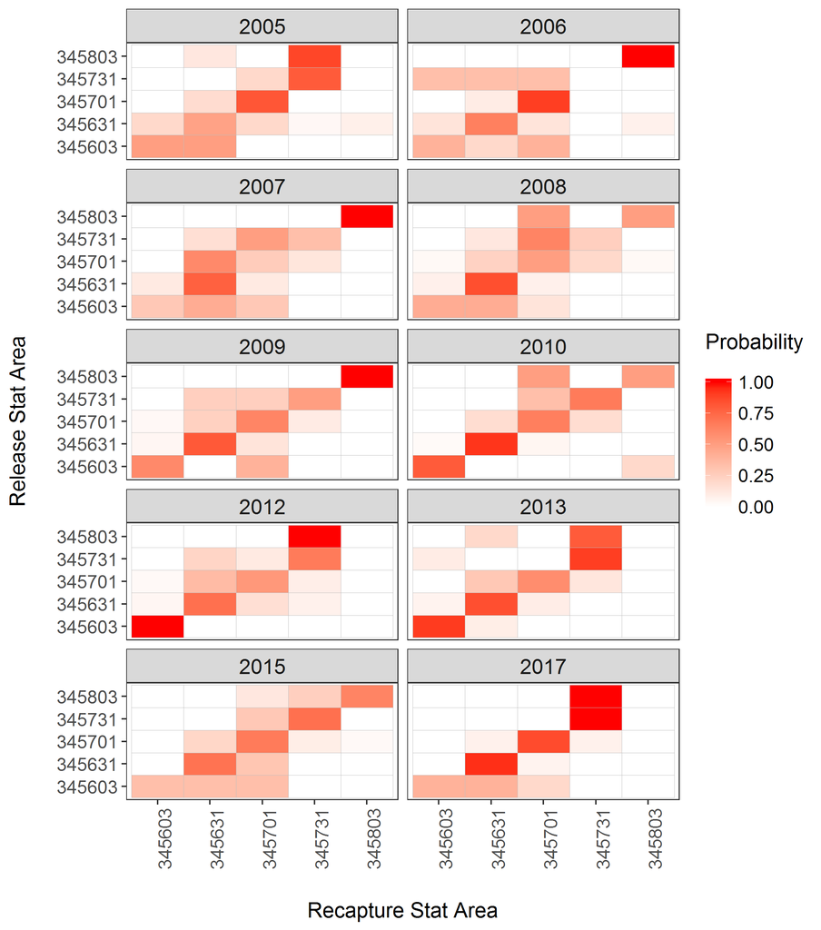

Figure 1. Longline survey CPUE in sablefish per hook (+/- 1 standard deviation), 1997 - 2017.

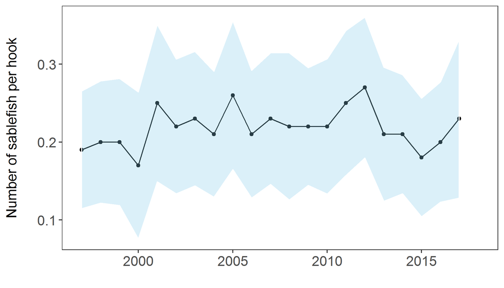

Figure 2. Commercial longline fishery CPUE in round pounds per hook (+/- 1 standard deviation), 1997 - 2017.

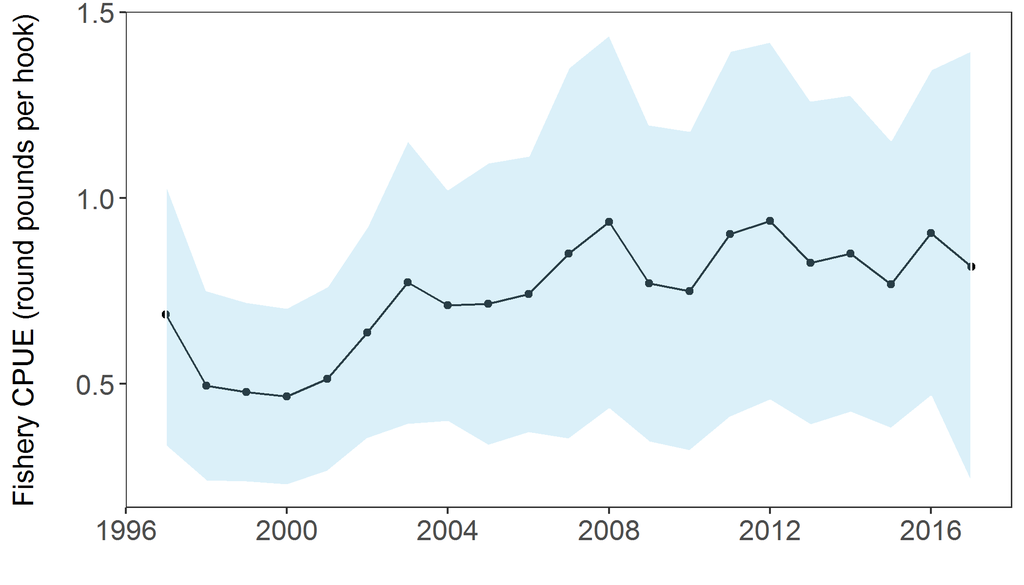

Figure 6. Centered and scaled abundance estimates from four mark-recapture models over a range of different numbers of time periods for years with a mark survey, 2005 - 2017.

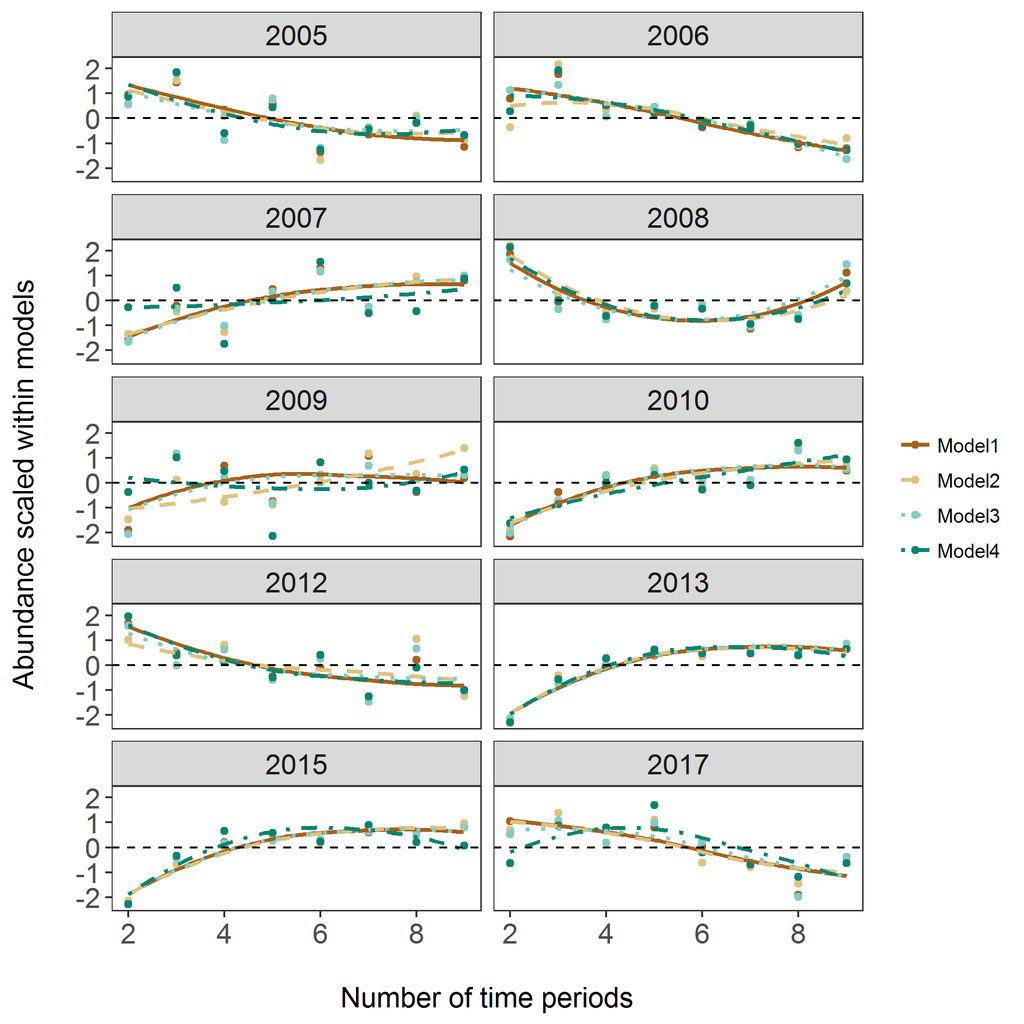

Figure 7. Posterior distribution of net migration into Chatham Strait with 95% credibility intervals shaded (Model 2, P=6). The median point estimate is denoted in the red dashed line. The solid blue line at net 0 migration aids in visualization of results across years with a mark survey, 2005 - 2017.

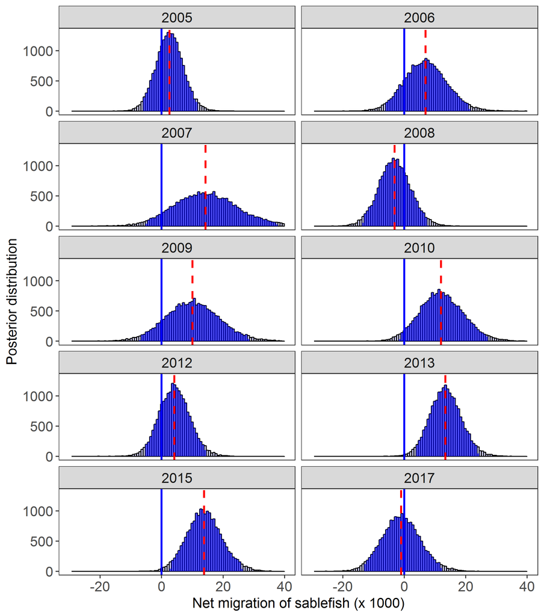

Figure 8. Observed (black) versus fitted (grey) CPUE (sablefish per 1000 hooks) in the longline fishery (Model 3, P=6) for years with a mark survey, 2005 - 2017. Grey shaded areas indicate 95% credibility intervals from the posterior distribution.

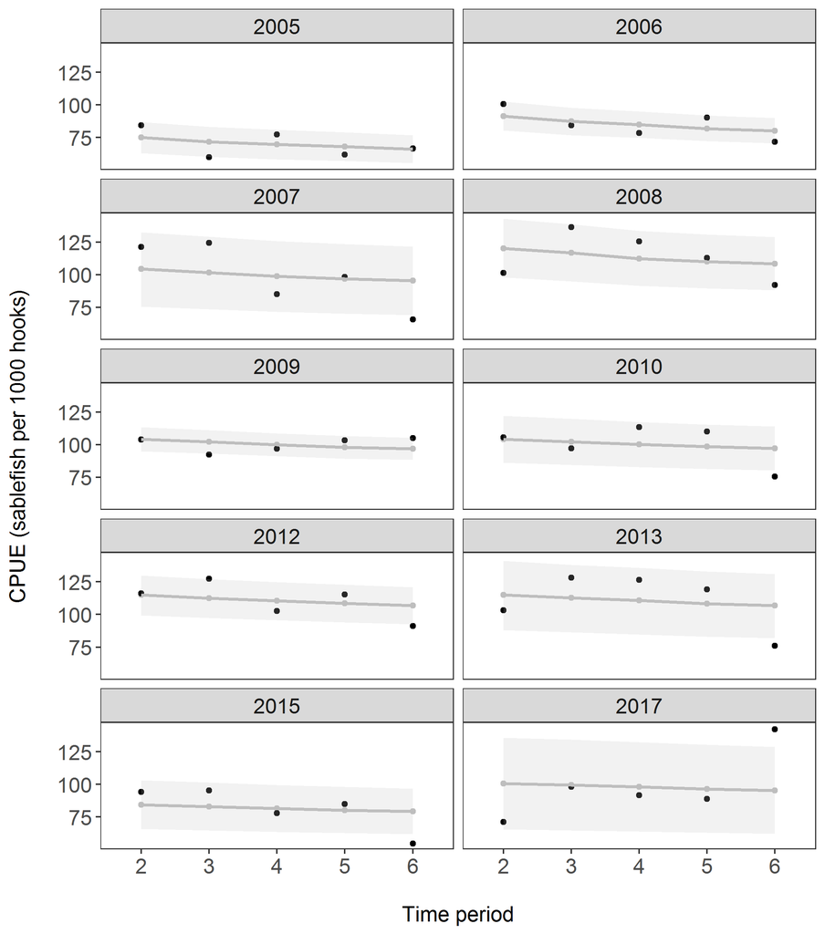

Figure 9. A retrospective analysis of abundance estimates from the current model (red) against previous estimates of abundance (teal) from 2005 - 2017. Shaded areas indicate 95% credibility intervals from the posterior distribution. The teal star shows the past forecast of abundance in 2017, which was poorly estimated due to a lack of a mark survey in 2016.

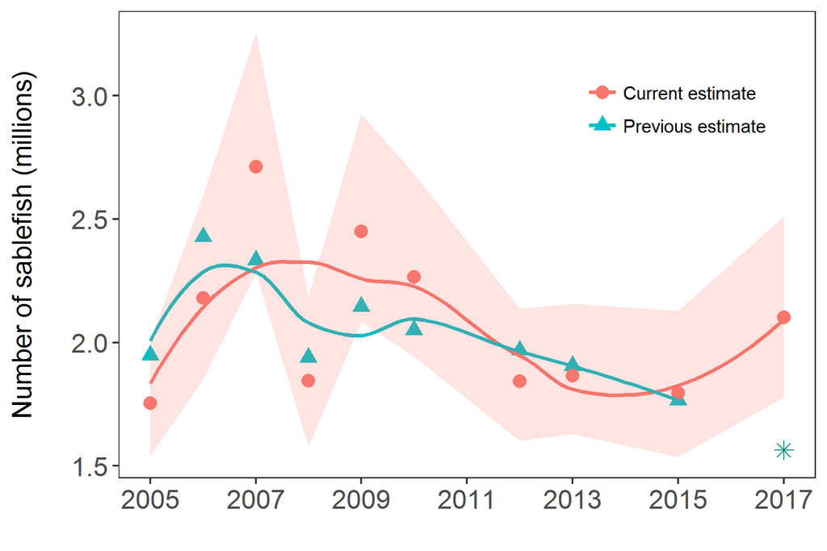

# References

Burnham, K.P. and Anderson, D.R. 2003. Model selection and multimodel inference: a practical information-theoretic approach. Springer Science & Business Media.

Depaoli, S., James P. Clifton, and Patrice R. Cobb. 2016. “Just Another Gibbs Sampler (JAGS) Flexible Software for MCMC Implementation.” Journal of Educational and Behavioral Statistics 41.6: 628-649.

Dressel, S.C. 2009. 2006 Northern Southeast Inside sablefish stock assessment and 2007 forecast and quota. Alaska Department of Fish and Game, Fishery Data Series No. 09-50, Anchorage.

de Leeuw, J., Reproducible Research. The Bottom Line, Department of Statistics, UCLA, Department of Statistics Papers, Paper 2001031101, March 2001. Available online at https://escholarship.org/uc/item/9050x4r4

Gelman, A and Rubin, DB (1992) Inference from iterative simulation using multiple sequences, Statistical Science, 7, 457-511.

Mueter, F. 2010. Evaluation of stock assessment and modeling options to assess sablefish population levels and status in the Northern Southeast Inside (NSEI) management area. Alaska Department of Fish and Game, Special Publication No. 10-01, Anchorage.

Schwab M., M. Karrenbach, and J. Claerbout, Making scientific computations reproducible, Computing in Science & Engineering, vol. 2, no. 6, pp. 61–67, Nov. 2000. Available online at http://sepwww.stanford.edu/doku.php?id=sep:research:reproducible:cip.